# Lab 12 - Connectivity

```r
rm(list=ls())

require(tidyverse)
require(terra)
require(sf)
require(gdistance)
require(igraph)
require(fitdistrplus)
require(fdrtool)
```

# Functional connectivity among Florida Panther protected areas

Today we’re going to be working with two different data sets. First, we’ll be revisiting our panther data. This time, we’ll be trying to identify connectivity and potential corridors among protected lands in south Florida. Prior work used radio telemetry data to interpret landscape resistance based on point-selection and home range selection functions (https://www.sciencedirect.com/science/article/pii/S0006320705005495).

### Datasets

We’re going to be relying on two data sets here. The first is the same vegetation raster we’ve been working with the past few weeks, developed by the Florida Fish and Wildlife Conservation Commission. Secondly, we’ll use a shapefile showing boundaries for some protected areas in southern Florida.

```r
# Read in the landcover raster
land = rast('https://github.com/ValenteJJ/SpatialEcology/raw/main/Week10/panther_landcover.tif')

# Identify the crs of the landcover raster
crs(land)
```

```
## [1] "PROJCRS[\"unknown\",\n    BASEGEOGCRS[\"unknown\",\n        DATUM[\"Unknown based on GRS 1980 ellipsoid\",\n            ELLIPSOID[\"GRS 1980\",6378137,298.257222101004,\n                LENGTHUNIT[\"metre\",1],\n                ID[\"EPSG\",7019]]],\n        PRIMEM[\"Greenwich\",0,\n         …
```

```r
#Look at th raster's resolution
res(land)
```

```
## [1] 500 500
```

```r
# Bring in the public lands shapefile
public = st_read('/vsicurl/https://github.com/ValenteJJ/SpatialEcology/raw/main/Week12/panther_publicland.shp')
# Set the crs of the public lands shapefile
st_crs(public) = crs(land)

# And look at it
data.frame(public)
```

|  | OBJECTID | MA_ID | MACODE_BCD | MANAME | MAJORMA | MATYPE | MANAGING_A | MATYPE2 | OWNER | COOWNERS | TOTACRES | LTF_ACRES | COUNTY | PROTSTAT | MANAGER | MGRINST | MGRCITY | MGRPHONE | DESC1 | DESC2 | COMMENTS1 | COMMENTS2 | DIG_COM | MANAME_AB | DESCRIPT | FGDLAQDATE | AUTOID | geometry |
| --- | --- | --- | --- | --- | --- | --- | --- | --- | --- | --- | --- | --- | --- | --- | --- | --- | --- | --- | --- | --- | --- | --- | --- | --- | --- | --- | --- | --- |
| 1 | 9 | 160 | M.USFLHP*193 | FRED C. BABCOCK-CECIL M. WEBB WILDLIFE MANAGEMENT AREA | ZZ | SFWWM | FL FISH AND WILDLIFE CONSERVATION COMMISSION | S | FL FISH AND WILDLIFE CONSERVATION COMMISSION | ZZ | 80335.00 | NA | CHAR, LEEX | 3 | MIKE KEMMERER, BIOLOGICAL SCIENTIST III | FLORIDA FISH & WILDLIFE CONSERVATION COMMISSION | PUNTA GORDA | 941-575-5768 | LARGE AREA OF SOUTH FLORIDA SLASH PINE FLATWOODS CONTAINING ACTIVE RED-COCKADED WOODPECKER COLONIES. ALSO SUPPORTS FLORIDA BLACK BEAR, CRESTED CARACARA, A BIRD ROOKERY AND THE LARGEST KNOWN POPULATION… | S UNIT. | BOUNDARIES IN GIS (1998-07 PAPER QUAD BOUNDARIES ARE OUTDATED). THIS PROPERTY (EXCLUDING THE YUCCA PENS UNIT) IS OWNED BY FL FWCC; WAS PURCHASED WITH PITTMAN/ROBERTSON FUNDS. TOTACRES FROM EXCEL TABLE… | BY PATTI DOERR. BABCOCK-WEBB WMA INCLUDES YUCCA PENS UNIT (M.USFLHP*47). | FNAI MAPPING AND DIGITIZING | BABCOCK-WEBB WMA | FRED C. BABCOCK-CECIL M. WEBB WILDLIFE MANAGEMENT AREA | 2008-12-30 | 52 |  |
| 2 | 553 | 445 | M.USFLHP*130 | BIG CYPRESS NATIONAL PRESERVE | ZZ | FNPNP | US DEPT. OF THE INTERIOR, NATIONAL PARK SERVICE | F | US DEPT. OF INTERIOR, NATIONAL PARK SERVICE | ZZ | 720561.47 | NA | BROW, COLL, DADE, MONR | 1 | JOHN J. DONAHUE, SUPERINTENDENT | ZZ | OCHOPEE | 941-695-2000 | COVERING THE WEST HALF OF THE EVERGLADES, THIS PRESERVE IS A SPECTACULAR MAZE OF SWAMPLANDS AND FLATWOODS, WHICH ARE HOME TO PANTHERS, FLORIDA BLACK BEARS, BIRD ROOKERIES, AND ORCHIDS. THE FEDERAL GOV… | ESERVE BOUNDARY; REST IS OTHER PUBLIC LANDS AND PRIVATE INHOLDINGS. | BOUNDARIES IN GIS (1991-09 BOUNDARIES WERE DRAWN FROM MAP DATED 1987-04, DELIVERED TO FNAI BY MIA VAN HORN 1991-09). TOTACRES FROM 2008-03-17 NPS ACREAGE LIST SENT BY KAROL NEVILLE (EMAIL); INCLUDES 5… | ACRES IN THE ADDITION. AS OF 2008-03-17, THERE ARE 648114.57 ACRES OF FEDERAL LAND, 70706.09 ACRES OF OTHER PUBLIC LAND, AND 1740.81 ACRES OF PRIVATE LAND WITHIN THE PRESERVE BOUNDARY (PER NPS ACREAGE… | COMBINATION OF FNAI MAPPING AND DIGITIZING, AND DIGITAL BOUNDARIES PROVIDED BY COLLIER COUNTY PROPERTY APPRAISER. 02/2008 | BIG CYPRESS NATL PR | BIG CYPRESS NATIONAL PRESERVE | 2008-12-30 | 450 |  |
| 3 | 1029 | 999 | M.USFLHP*663 | OKALOACOOCHEE SLOUGH STATE FOREST | ZZ | SDFSF | FL DEPT. AGRICULTURE AND CONSUMER SERVICES, DIV. OF FORESTRY | S | SOUTH FLORIDA WATER MANAGEMENT DISTRICT | ZZ | 32039.24 | NA | COLL, HEND | 3 | GREG COX, FOREST AREA SUPERVISOR | FL DACS DIVISION OF FORESTRY | FELDA | 863-612-0776; (FAX) 863-612-0780 | A MAJOR HEADWATER FOR FAKAHATCHEE STRAND AND BIG CYPRESS NATIONAL PRESERVE, THIS PROPERTY CONTAINS THOUSANDS OF ACRES OF UNDISTURBED WETLANDS SURROUNDED BY HYDRIC HAMMOCKS DOMINATED BY OAK AND CABBAGE… | ZZ | BOUNDARIES IN GIS. OWNED BY SOUTH FLORIDA WMD AND MANAGED BY FL DACS DOF. FL FWCC IS A SECONDARY MANAGER, SINCE THIS PROPERTY IS ALSO MANAGED AS PART OF OKALOACOOCHEE SLOUGH WMA (SEE M.USFLHP*991). TO… | UDE TRACT OWNED BY FWCC AND UNDER LEAD MANAGEMENT BY THIS AGENCY. | DIGITAL BOUNDARIES PROVIDED BY FDACS DIV. OF FORESTRY. 02/2006 | OKALOACOOCHEE SLOUGH SF | OKALOACOOCHEE SLOUGH STATE FOREST | 2008-12-30 | 1110 |  |
| 4 | 1150 | 1060 | M.USFLHP*432 | KISSIMMEE PRAIRIE PRESERVE STATE PARK | ZZ | SRPSV | FL DEPT. OF ENVIRONMENTAL PROTECTION, DIV. OF RECREATION AND PARKS | S | TRUSTEES OF THE INTERNAL IMPROVEMENT TRUST FUND | SOUTH FLORIDA WATER MANAGEMENT DISTRICT, PRIVATE INDIVIDUAL | 53765.68 | NA | OKEE, OSCE | 1 | CHARLES BROWN | FL DEP DIVISION OF RECREATION AND PARKS | OKEECHOBEE | 863-462-5360; FAX 863-462-5276 | THIS PRESERVE ENCOMPASSES A VAST EXPANSE OF DRY PRAIRIE DIVIDED BY SLOUGHS THAT SUPPORT MESIC AND HYDRIC HAMMOCK. SMALL PATCHES OF SCRUB, XERIC AND MESIC HAMMOCK ARE PRESENT ON HISTORIC LEVEES NEAR TH… | GE FLORIDA GRASSHOPPER SPARROW POPULATION AND PROVIDES HABITAT FOR MANY OTHER BIRD SPECIES. | BOUNDARIES IN GIS. TOTACRES FROM 2002-07 DRP LIST; INCLUDES 51912.65 UPLAND ACRES AND 1853.03 SUBMERGED ACRES). 45621.87 ACRES BELONG TO TRUSTEES (TIITF), 8123.81 ACRES ARE LEASED FROM SOUTH FLORIDA W… | Y-WHITTELL KISSIMMEE PRAIRIE SANCTUARY, FORMERLY OWNED AND MANAGED BY THE NATIONAL AUDUBON SOCIETY, WAS PURCHASED BY THE STATE 2001-11-15 AND WAS ADDED TO THE PRESERVE 2002-06-06 (7311.4 ACRES LEASED … | DIGITAL BOUNDARIES PROVIDED BY FL DEP DIV. OF RECREATION AND PARKS. 04/2006 | KISSIMMEE PRAIRIE PR SP | KISSIMMEE PRAIRIE PRESERVE STATE PARK | 2008-12-30 | 1240 |  |
| 5 | 1345 | 1341 | M.USFLHP*1124 | FLORIDA PANTHER NATIONAL WILDLIFE REFUGE | ZZ | FFWWR | US DEPT. OF THE INTERIOR, FISH AND WILDLIFE SERVICE | F | US FISH & WILDLIFE SERVICE | ZZ | 26605.42 | NA | COLL | 2 | LAYNE HAMILTON, REFUGE MANAGER | U. S. FISH & WILDLIFE SERVICE | NAPLES | 239-353-8442 EXT. 227 | LOCATED APPROXIMATELY 20 MILES EAST OF NAPLES, FLORIDA. THE PRIMARY MISSION OF THIS REFUGE IS TO PROTECT HABITAT FOR THE FEDERALLY ENDANGERED FLORIDA PANTHER AND OTHER WILDLIFE. THE REFUGE IS CLOSED F… | PRESS AND MIXED SWAMP FORESTS, FLATWOODS, HARDWOOD HAMMOCKS, PRAIRIES, MARSHES, AND SLOUGHS. PERMANENT AND SEASONAL WETLANDS COMPRISE APPROXIMATELY 70% OF THE REFUGE ACREAGE. | BOUNDARIES IN GIS (1993-09 BOUNDARIES ON PAPER QUADS ARE OUTDATED, WERE DRAWN FROM STATUS MAP POSTED 1992-12). TOTACRES FROM UPDATED LIST OF ACREAGES FOR FLORIDA NWRS SENT BY CHARLOTTE UNDERWOOD 2007-… | NT OR LEASE (ROAD RIGHT-OF-WAYS, PER LAYNE HAMILTON). | DIGITAL BOUNDARIES PROVIDED BY U. S. FISH AND WILDLIFE SERVICE. 02/2008 | FLORIDA PANTHER NWR | FLORIDA PANTHER NATIONAL WILDLIFE REFUGE | 2008-12-30 | 1284 |  |

For mapping connectivity among these public lands, we need to identify a point in space from which to do the mapping. Thus, we’re going to calculate the centroid of each park which is the center of the mass.

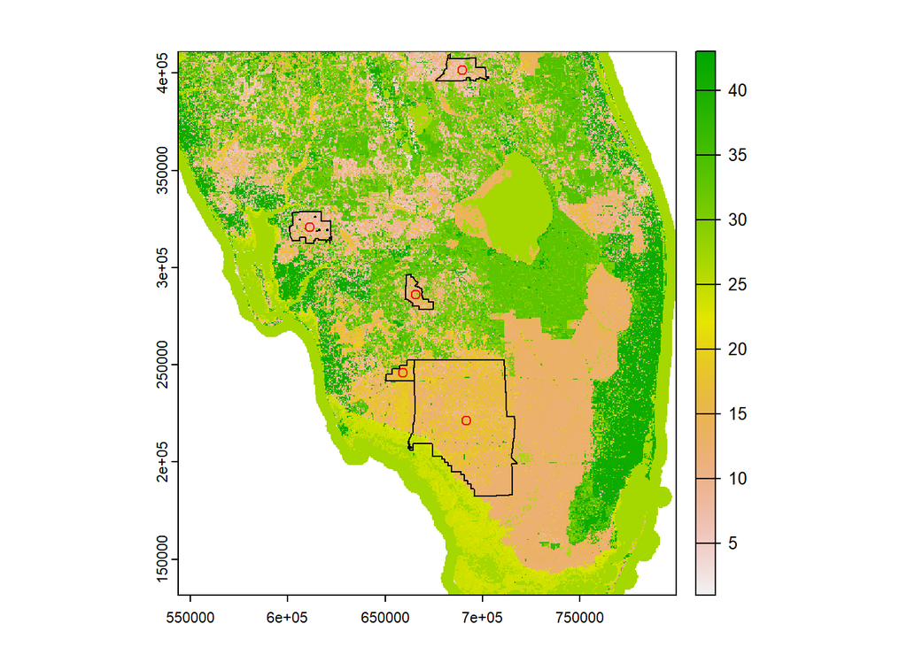

```r
publicCentroids = st_centroid(public)

plot(land)
plot(st_geometry(public), add=T)
plot(st_geometry(publicCentroids), add=T, col='red')
```

We are now going to reclassify this landcover map to represent resistance. To do this, just bring in the table below and use the classify() function. Here higher values represent greater resistance to movement. These values were generated from the paper I referenced above, so have a read if you want more information about how we got to these resistance values. For our purposes, just take these numbers at face value.

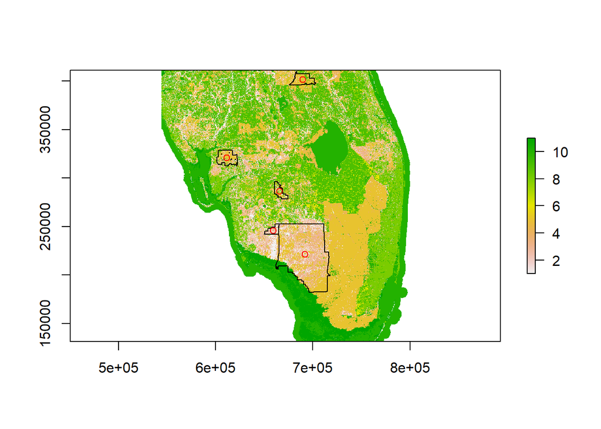

```r
classification = read.table('https://raw.githubusercontent.com/ValenteJJ/SpatialEcology/main/Week12/resistance%20reclass.txt', header=T)
landCost = classify(land, classification[,c(1,3)])
landCost = raster(landCost)

plot(landCost)
plot(st_geometry(public), add=T)
plot(st_geometry(publicCentroids), add=T, col='red')
```

# Effective distances

There are several ways to calculate “distances” between protected areas, and we will consider 4 of them. The most straightforward metric is Euclidean distance, also known as straight-line distance. This totally ignores the resistance of the landscape and simply assumes that those protected areas that are physically closer are also more connected.

```r
#Euclidean distance

geoDist = pointDistance(publicCentroids, lonlat=F)
geoDist = as.dist(geoDist)
```

Next we will consider the least-cost distance which is the shortest distance between two points based on sum of costs. We can quantify this either in terms of least-cost distance (cumulative cost of the path) or least-cost path length (actual length of the path that has the least cost). Before we can calculate this, however, we need to use the gdistance package to create a transition layer. This converts the raster cells into a sparse network of connections based on the mean conductance value (1/resistance) between pairs of cells

```r
# Calculate conductance transition matrix
landCond = transition(1/landCost, transitionFunction = mean, 8)

#Do a geographic correction of the conductance values to "correct" for the fact that there are further distances between cells that touch on the diagonal
landCond = geoCorrection(landCond, type='c', multpl=F)
```

Now we can calculate the actual least-cost distance using Dijkstra’s algorithm.

```r
#Least-cost distance
lcDist = costDistance(landCond, st_coordinates(publicCentroids))
lcDist
```

```
##           1         2         3         4
## 2 250607.85
## 3 179140.02 131344.61
## 4 318972.02 470623.60 339278.98
## 5 191449.65  63048.06  85583.67 424862.66
```

Now we will calculate an effective distance based on circuit theory. We assume random walks, acknowledging that different paths are possible. The commute distance function quantifies the expected time for an individual to move from one point to another in number of steps.

```r
#Commute distance
circuitDist = commuteDistance(landCond, st_coordinates(publicCentroids))
circuitDist
```

```
##           1         2         3         4
## 2 1337632.6
## 3 1221718.7  883745.4
## 4 1675535.7 1585787.1 1513399.0
## 5 1271736.3  675481.3  823479.5 1566043.6
```

We could also calculate a randomized shortest path. Recall, that here we have a parameter theta that we can tweak. If theta = 0, our analysis is analogous to a circuit theory approach and as theta increases, we approach a least-cost path. In this case, the rSPDistance() function takes an unfortunately long time, so we are going to subset to just the first two points for this exercise in class.

```r
#Randomized shortest path distance
rspDist1.2 = rSPDistance(landCond, from=st_coordinates(publicCentroids)[1,], to=st_coordinates(publicCentroids)[2,], theta=0.001)
rspDist1.2
```

```
##          [,1]
## [1,] 310205.9
```

# Mapping least-cost paths

The above code helped us calculate the effective distances among the protected areas, but this is spatial ecology, and we’re interested in mapping the literal paths. For this, we’re going to subset our protected areas and focus in on two of them: the Florida Panther Wildlife Refuge, and the Okaloacoochee Slough State Forest. To speed up computation, we’re going to crop our raster layer to a region relevant to these two protected areas.

```r
# Choose the extent for cropping
fpwrOssfExtent = extent(642000, 683000, 237000, 298000)

# Crop the landcover layer
landSub = crop(land, fpwrOssfExtent)

# Crop the cost layer and create a transition matrix
landCostSub = crop(landCost, fpwrOssfExtent)
landCondSub = transition(1/landCostSub, transitionFunction=mean, 8)
landCondSub = geoCorrection(landCondSub, type='c', multpl=F)
```

Now we can use the shortestPath() function to actually map the least-cost path.

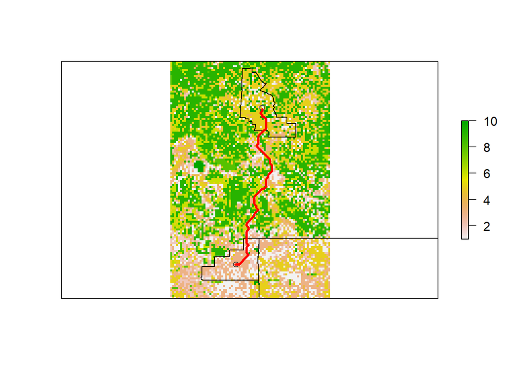

```r
fpwrOssfLcp = shortestPath(landCond, st_coordinates(publicCentroids)[5,], st_coordinates(publicCentroids[3,]), output='SpatialLines')

plot(landCostSub, axes=F)
plot(st_geometry(public), add=T)
plot(st_geometry(publicCentroids), col='grey30', add=T)
lines(fpwrOssfLcp, col='red', lwd=3)
```

# Least-cost Corridors

One major criticism of least-cost path analysis is that it focuses only on a single line, and thus sort of assumes that all individuals are going to take that one optimal path. One potential alternative is to instead map a least-cost corridor. This requires a few steps. First, we’re going to calculate the accumulated cost surface from our two points.

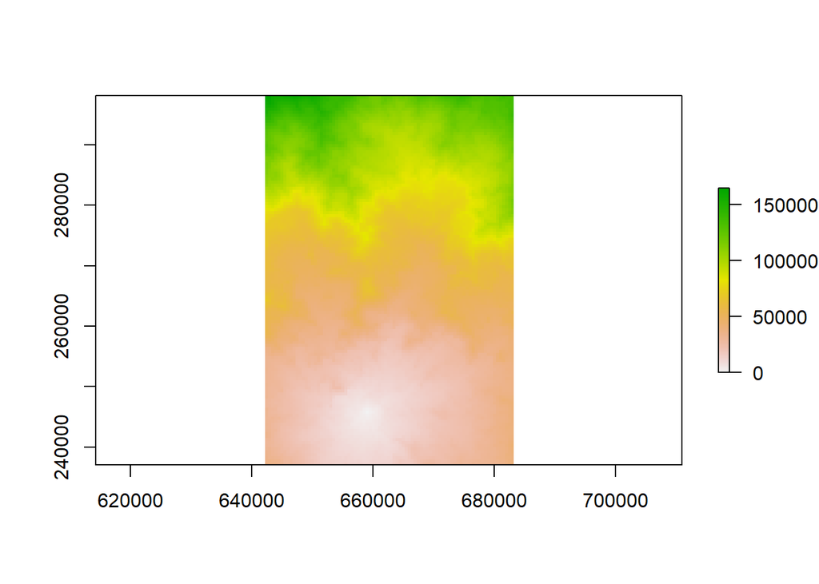

```r
fpwrCost = accCost(landCondSub, st_coordinates(publicCentroids)[5,])
ossfCost = accCost(landCondSub, st_coordinates(publicCentroids)[3,])

plot(fpwrCost)
```

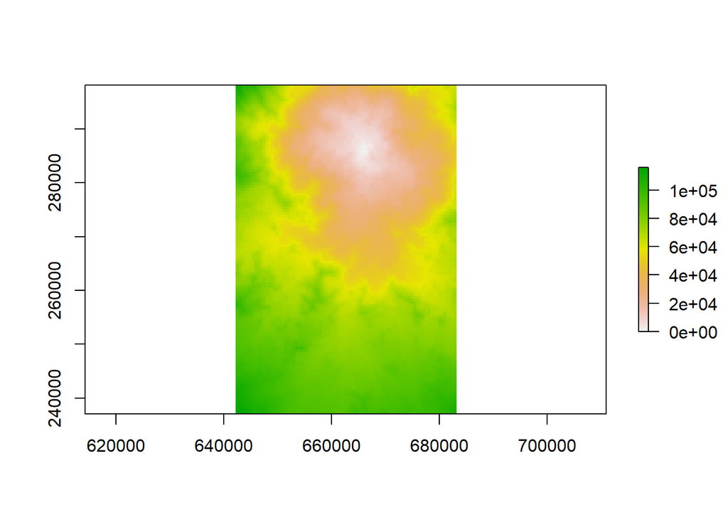

```r
plot(ossfCost)
```

Now we can sum the cumulative values for each cell.

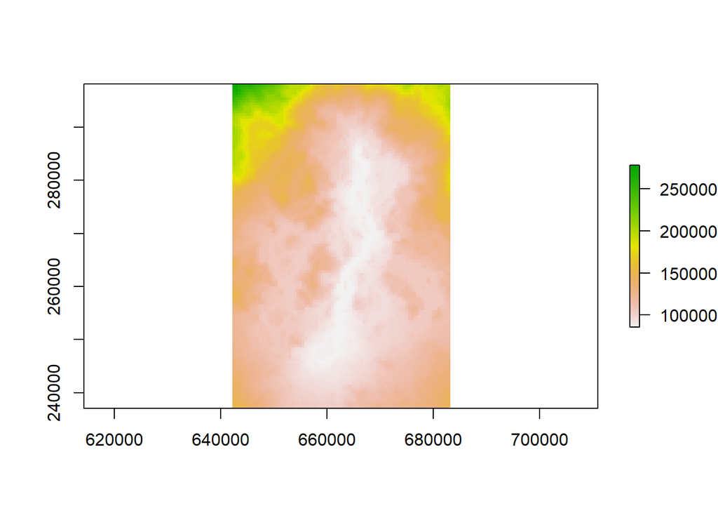

```r
leastCostCorridor = overlay(fpwrCost, ossfCost, fun=function(x, y){return(x+y)})

plot(leastCostCorridor)
```

A clear corridor starts to jump out, and now we can filter to those pixels which have the easiest paths. Here, we’re going to focus on the 10% of pixels with the least summed cost.

```r
#Calculate the 10% quantile for the leastCostCorridor raster
quantile10 = quantile(leastCostCorridor, probs=0.1, na.rm=T)
quantile10
```

```
##      10%
## 91850.34
```

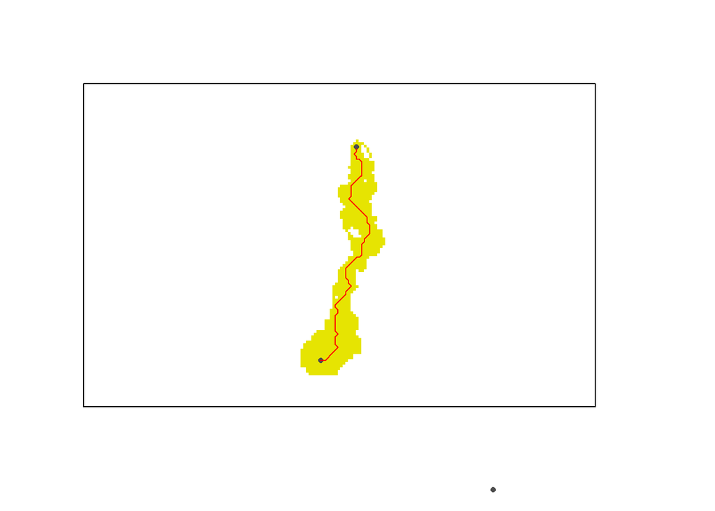

```r
#Create a new raster with a value of 1 if it has a summed cost in the lower 10% and a NA otherwise
leastCostCorridor10 = leastCostCorridor
values(leastCostCorridor10) = NA
leastCostCorridor10[leastCostCorridor < quantile10] = 1

#Plot this raster and look at it
plot(leastCostCorridor10, legend=F, axes=F)
points(publicCentroids, col='grey30')
lines(fpwrOssfLcp, col='red')
```

Now that we have these spatially explicit objects, we can use them to extract information for these paths or corridors for conservation planning purposes. You’ll be doing this for one of the challenges in your lab.

# Randomized shortest path (flow mapping)

We can contrast our LCP approach above with a randomized shortest path analysis. Again, we are going to assume a random walk for an individual that is biased based on the resistance encountered. The passage() function quantifies the number of potential movements through cells before arriving in a destination location from a source location.

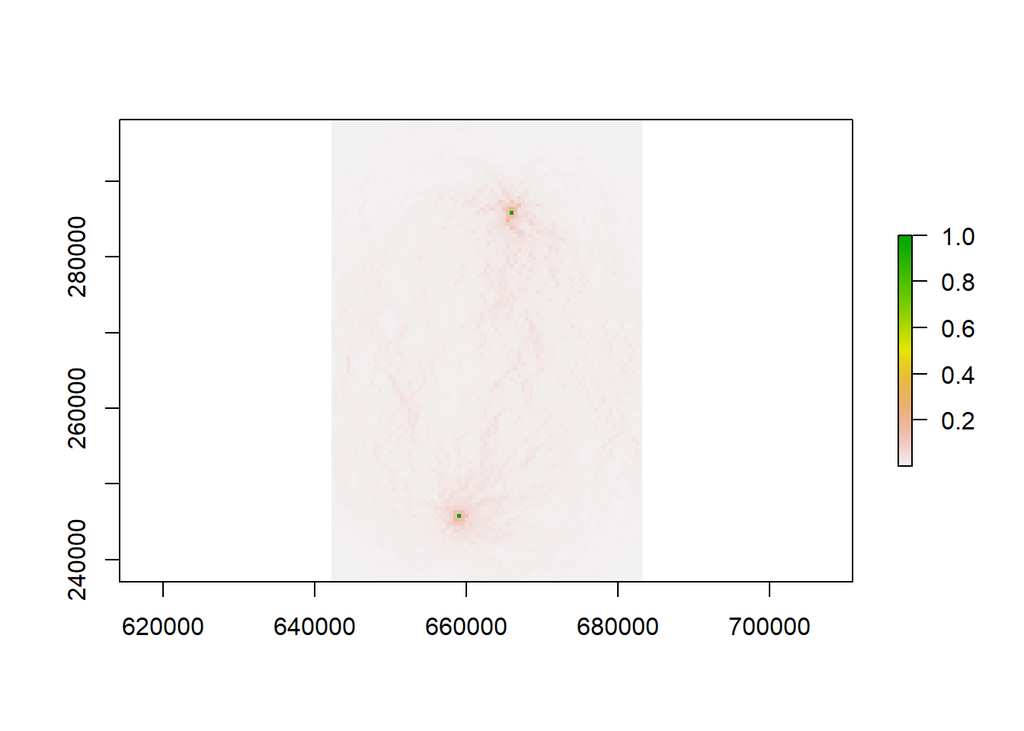

```r
#Random walk

passageMapT0 = passage(landCondSub, origin = st_coordinates(publicCentroids)[3,], goal = st_coordinates(publicCentroids)[5,], theta=0)

plot(passageMapT0)
```

Note that when theta is set to 0, movement probability in each cell is very low and movement is thus very diffuse. Thus we are developing a circuit-theory based solution to our assessment of movement. Theta is the degree from which the path randomly deviates from the shortest path.

# Patch-based networks and graph theory

Now we’re going to switch gears and demonstrate the use of patch-based graphs or networks to evaluate connectivity. Importantly, we’re going to be working with a completely different dataset and comparing potential vs. realized connectivity among 29 sites for the endangered Snail Kite. First we’re going to bring in a node-specific data frame that has name, coordinate, and area information for the 29 sites.

We’re going to bring in two datasets.

```r
nodes = read.csv('https://raw.githubusercontent.com/ValenteJJ/SpatialEcology/main/Week12/kite_nodes.csv')
area = nodes$area
nodes
```

| Name | XCoord | YCoord | area |
| --- | --- | --- | --- |
| BICY | 495505 | 2849390 | 848.2403875 |
| DEVILS | 497670 | 2925290 | 0.6780510 |
| ENP | 531302 | 2840110 | 638.3016839 |
| ETOHO | 472324 | 3130400 | 47.5983906 |
| GW | 582883 | 2962720 | 20.2262642 |
| HarnsMarsh | 431024 | 2948020 | 2.2809754 |
| HOLEY | 526531 | 2917990 | 143.6203120 |
| HUNGRY | 569598 | 2983060 | 46.5866850 |
| IST | 472176 | 3028470 | 109.8500706 |
| KISS | 473993 | 3087280 | 145.0277254 |

[output cut: 19 more lines]

Next we will bring in a matrix showing within-breeding-season dispersal. The values in the matrix represent the observed number of Snail Kites that moved between each combination of sites. Note that this is not a symmetric matrix, meaning that we have bi-directional information.

```r
aObs = read.csv('https://raw.githubusercontent.com/ValenteJJ/SpatialEcology/main/Week12/kite_movement.csv')[,-1]
diag(aObs) = 0
aObs
```

| V1 | V2 | V3 | V4 | V5 | V6 | V7 | V8 | V9 | V10 | V11 | V12 | V13 | V14 | V15 | V16 | V17 | V18 | V19 | V20 | V21 | V22 | V23 | V24 | V25 | V26 | V27 | V28 | V29 |
| --- | --- | --- | --- | --- | --- | --- | --- | --- | --- | --- | --- | --- | --- | --- | --- | --- | --- | --- | --- | --- | --- | --- | --- | --- | --- | --- | --- | --- |
| 0 | 0 | 0 | 0 | 0 | 0 | 0 | 0 | 0 | 0 | 0 | 0 | 0 | 0 | 0 | 0 | 0 | 0 | 0 | 0 | 0 | 0 | 0 | 0 | 0 | 0 | 0 | 0 | 0 |
| 0 | 0 | 0 | 0 | 0 | 0 | 0 | 0 | 0 | 0 | 0 | 0 | 0 | 0 | 0 | 0 | 0 | 0 | 0 | 0 | 0 | 0 | 0 | 0 | 0 | 0 | 0 | 0 | 0 |
| 0 | 0 | 0 | 0 | 1 | 0 | 0 | 0 | 0 | 0 | 0 | 0 | 0 | 0 | 0 | 0 | 0 | 0 | 0 | 0 | 0 | 0 | 0 | 0 | 0 | 1 | 1 | 0 | 0 |
| 0 | 0 | 0 | 0 | 0 | 0 | 0 | 0 | 2 | 11 | 0 | 0 | 0 | 2 | 0 | 0 | 17 | 5 | 0 | 0 | 0 | 0 | 0 | 10 | 0 | 0 | 0 | 0 | 0 |
| 0 | 0 | 0 | 0 | 0 | 0 | 0 | 0 | 0 | 0 | 0 | 0 | 0 | 0 | 0 | 0 | 0 | 0 | 0 | 1 | 0 | 0 | 0 | 0 | 0 | 1 | 1 | 0 | 0 |
| 0 | 0 | 0 | 0 | 0 | 0 | 0 | 0 | 0 | 0 | 0 | 0 | 0 | 0 | 0 | 0 | 0 | 1 | 0 | 0 | 0 | 0 | 0 | 1 | 0 | 0 | 0 | 0 | 0 |
| 0 | 0 | 0 | 0 | 0 | 0 | 0 | 0 | 0 | 0 | 0 | 0 | 0 | 0 | 0 | 0 | 0 | 0 | 0 | 0 | 0 | 0 | 0 | 0 | 0 | 0 | 0 | 0 | 0 |
| 0 | 0 | 0 | 0 | 0 | 0 | 0 | 0 | 0 | 0 | 0 | 0 | 0 | 0 | 0 | 0 | 0 | 0 | 0 | 0 | 0 | 0 | 0 | 0 | 0 | 0 | 0 | 0 | 0 |
| 0 | 0 | 0 | 0 | 0 | 0 | 0 | 0 | 0 | 2 | 0 | 0 | 0 | 0 | 0 | 0 | 0 | 1 | 0 | 0 | 0 | 0 | 2 | 1 | 0 | 0 | 0 | 0 | 0 |
| 0 | 0 | 0 | 13 | 1 | 0 | 0 | 0 | 5 | 0 | 0 | 0 | 0 | 1 | 0 | 0 | 3 | 18 | 0 | 3 | 0 | 0 | 1 | 48 | 0 | 0 | 1 | 0 | 0 |

[output cut: 19 more lines]

Now we can create a distance matrix quantifying how far apart the sites are from one another in km.

```r
coords = cbind(nodes$XCoord, nodes$YCoord)
distMat = pointDistance(coords, lonlat=F)
distMat = distMat / 1000 # in km
distMat
```

```
##            [,1]      [,2]      [,3]       [,4]      [,5]      [,6]      [,7]
##  [1,]   0.00000  75.93087  36.98031 281.964499 143.10347 117.83750  75.28992
##  [2,]  75.93087   0.00000  91.57917 206.670104  93.07126  70.41550  29.76991
##  [3,]  36.98031  91.57917   0.00000 296.220675 133.01809 147.31003  78.02600
##  [4,] 281.96450 206.67010 296.22068   0.000000 200.84789 186.99774 219.21772
##  [5,] 143.10347  93.07126 133.01809 200.847890   0.00000 152.56882  71.94665
##  [6,] 117.83750  70.41550 147.31003 186.997739 152.56882   0.00000 100.11687
##  [7,]  75.28992  29.76991  78.02600 219.217716  71.94665 100.11687   0.00000
##  [8,] 152.83142  92.25514 147.99083 176.553977  24.29417 142.93549  78.03122
##  [9,] 180.59316 106.28291 197.42182 101.930107 128.75986  90.36421 123.12716
## [10,] 238.86067 163.71121 253.72688  43.152288 165.44554 145.73840 177.25503
## [11,] 117.22234  51.04710 140.00161 169.038197 121.01143  33.74282  78.03539
## [12,] 258.04741 183.08540 273.26274  24.753922 183.50949 162.28823 196.83777
## [13,] 253.37885 179.01276 269.79689  32.730882 184.63787 154.86972 194.11347
## [14,] 237.99453 162.38991 251.47406  44.857074 158.85685 148.86453 174.36719
```

[output cut: 135 more lines]

### Dispersal Kernels

Dispersal kernels quantify the dispersal probability as a function of distance from some original location (e.g., natal site or breeding site). Here we are creating dispersal kernels based on within-season movements. What this means is that we are trying to fit a model that represents the distribution of dispersal distances. So we need to pull together the non-zero movement distances and plot them.

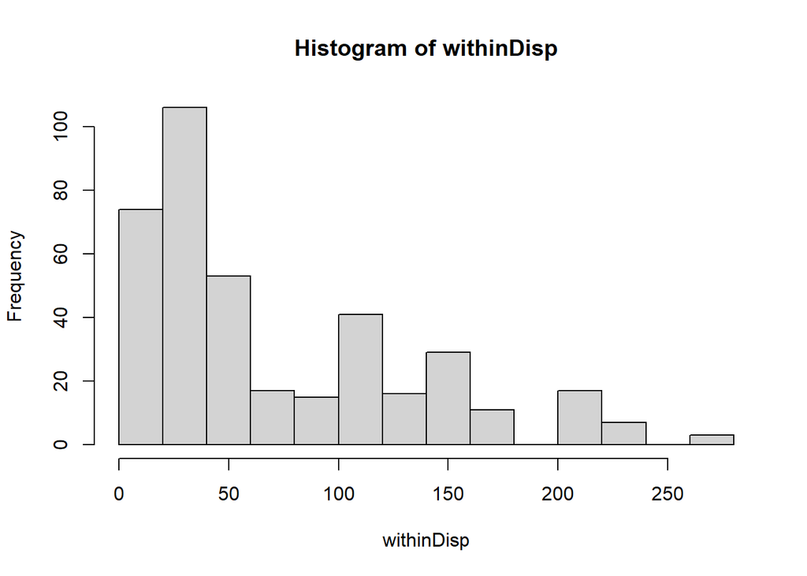

```r
linkLoc = which(aObs > 0, arr.ind=T)
withinDisp = cbind(distMat[linkLoc], aObs[linkLoc])

#Creating one distance observation for each individual
withinDisp = rep(withinDisp[,1], withinDisp[,2])

hist(withinDisp)
```

Now we can fit 4 different models that could potentially represent this observed distribution. We will focus on the log-normal distribution, exponential, Weibull, and halfnormal.

```r
dispLnorm = fitdist(data = withinDisp, distr='lnorm', method='mle')
dispExp = fitdist(data = withinDisp, distr='exp', method='mle')
dispWeib = fitdist(data=withinDisp, distr='weibull', method='mle')
disp1dt = fitdist(data=withinDisp, distr='halfnorm', start=list(theta=0.01), method='mle')

dispAic = gofstat(list(dispExp, dispLnorm, dispWeib, disp1dt), fitnames=c('exponential', 'lognormal', 'Weibull', '1Dt'))
dispAic$aic
```

```
## exponential   lognormal     Weibull         1Dt
##    4110.798    4111.573    4093.400    4103.977
```

It looks like the Weibull distribution fits best, based on AIC. Nonetheless, we’re going to use the exponential distribution given it is commonly used in metapopulation ecology and landscape connectivity research. This requires only one parameter, alpha, which describes the inverse of the mean dispersal distance for a species, and this information is relatively frequently available.

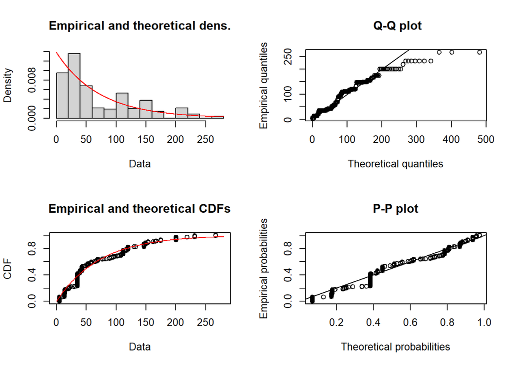

```r
plot(dispExp)
```

### Creating a network or graph

Given our chosen dispersal kernel, we can now create graphs based on different transition matrices. Note that we already have one directed, weighted network in aObs.

```r
aObs
```

| V1 | V2 | V3 | V4 | V5 | V6 | V7 | V8 | V9 | V10 | V11 | V12 | V13 | V14 | V15 | V16 | V17 | V18 | V19 | V20 | V21 | V22 | V23 | V24 | V25 | V26 | V27 | V28 | V29 |
| --- | --- | --- | --- | --- | --- | --- | --- | --- | --- | --- | --- | --- | --- | --- | --- | --- | --- | --- | --- | --- | --- | --- | --- | --- | --- | --- | --- | --- |
| 0 | 0 | 0 | 0 | 0 | 0 | 0 | 0 | 0 | 0 | 0 | 0 | 0 | 0 | 0 | 0 | 0 | 0 | 0 | 0 | 0 | 0 | 0 | 0 | 0 | 0 | 0 | 0 | 0 |
| 0 | 0 | 0 | 0 | 0 | 0 | 0 | 0 | 0 | 0 | 0 | 0 | 0 | 0 | 0 | 0 | 0 | 0 | 0 | 0 | 0 | 0 | 0 | 0 | 0 | 0 | 0 | 0 | 0 |
| 0 | 0 | 0 | 0 | 1 | 0 | 0 | 0 | 0 | 0 | 0 | 0 | 0 | 0 | 0 | 0 | 0 | 0 | 0 | 0 | 0 | 0 | 0 | 0 | 0 | 1 | 1 | 0 | 0 |
| 0 | 0 | 0 | 0 | 0 | 0 | 0 | 0 | 2 | 11 | 0 | 0 | 0 | 2 | 0 | 0 | 17 | 5 | 0 | 0 | 0 | 0 | 0 | 10 | 0 | 0 | 0 | 0 | 0 |
| 0 | 0 | 0 | 0 | 0 | 0 | 0 | 0 | 0 | 0 | 0 | 0 | 0 | 0 | 0 | 0 | 0 | 0 | 0 | 1 | 0 | 0 | 0 | 0 | 0 | 1 | 1 | 0 | 0 |
| 0 | 0 | 0 | 0 | 0 | 0 | 0 | 0 | 0 | 0 | 0 | 0 | 0 | 0 | 0 | 0 | 0 | 1 | 0 | 0 | 0 | 0 | 0 | 1 | 0 | 0 | 0 | 0 | 0 |
| 0 | 0 | 0 | 0 | 0 | 0 | 0 | 0 | 0 | 0 | 0 | 0 | 0 | 0 | 0 | 0 | 0 | 0 | 0 | 0 | 0 | 0 | 0 | 0 | 0 | 0 | 0 | 0 | 0 |
| 0 | 0 | 0 | 0 | 0 | 0 | 0 | 0 | 0 | 0 | 0 | 0 | 0 | 0 | 0 | 0 | 0 | 0 | 0 | 0 | 0 | 0 | 0 | 0 | 0 | 0 | 0 | 0 | 0 |
| 0 | 0 | 0 | 0 | 0 | 0 | 0 | 0 | 0 | 2 | 0 | 0 | 0 | 0 | 0 | 0 | 0 | 1 | 0 | 0 | 0 | 0 | 2 | 1 | 0 | 0 | 0 | 0 | 0 |
| 0 | 0 | 0 | 13 | 1 | 0 | 0 | 0 | 5 | 0 | 0 | 0 | 0 | 1 | 0 | 0 | 3 | 18 | 0 | 3 | 0 | 0 | 1 | 48 | 0 | 0 | 1 | 0 | 0 |

[output cut: 19 more lines]

We can also create an undirected, unweighted network based on the mean dispersal distance. Here we are simply assuming that if two sites are closer together than the mean dispersal distance for the Kites, they are connected, and otherwise they are not.

```r
# Calculate mean dispersal distance
aMeanDist = mean(withinDisp)
aMeanDist
```

```
## [1] 72.32945
```

```r
# Create the transition matrix
aMean = matrix(0, nrow=nrow(aObs), ncol=ncol(aObs))
aMean[distMat < aMeanDist] = 1
diag(aMean) = 0
aMean
```

```
##       [,1] [,2] [,3] [,4] [,5] [,6] [,7] [,8] [,9] [,10] [,11] [,12] [,13]
##  [1,]    0    0    1    0    0    0    0    0    0     0     0     0     0
##  [2,]    0    0    0    0    0    1    1    0    0     0     1     0     0
##  [3,]    1    0    0    0    0    0    0    0    0     0     0     0     0
##  [4,]    0    0    0    0    0    0    0    0    0     1     0     1     1
##  [5,]    0    0    0    0    0    0    1    1    0     0     0     0     0
##  [6,]    0    1    0    0    0    0    0    0    0     0     1     0     0
##  [7,]    0    1    0    0    1    0    0    0    0     0     0     0     0
##  [8,]    0    0    0    0    1    0    0    0    0     0     0     0     0
##  [9,]    0    0    0    0    0    0    0    0    0     1     1     0     0
## [10,]    0    0    0    1    0    0    0    0    1     0     0     1     1
## [11,]    0    1    0    0    0    1    0    0    1     0     0     0     0
## [12,]    0    0    0    1    0    0    0    0    0     1     0     0     1
## [13,]    0    0    0    1    0    0    0    0    0     1     0     1     0
## [14,]    0    0    0    1    0    0    0    0    1     1     0     1     1
```

[output cut: 75 more lines]

Lastly, we will try creating an undirected, weighted network where the weights are based on the exponential distribution. Here we are going to use our mean dispersal distance as our estimate for alpha.

```r
aProb = matrix(0, nrow=nrow(aObs), ncol=ncol(aObs))
alpha = 1/aMeanDist

# Calculate weights in the distance matrix
aProb = exp(-alpha*distMat)
diag(aProb)=0
aProb
```

```
##             [,1]       [,2]       [,3]       [,4]       [,5]       [,6]
##  [1,] 0.00000000 0.35001058 0.59972982 0.02027562 0.13827716 0.19609083
##  [2,] 0.35001058 0.00000000 0.28191790 0.05742108 0.27616174 0.37774407
##  [3,] 0.59972982 0.28191790 0.00000000 0.01664848 0.15896703 0.13046458
##  [4,] 0.02027562 0.05742108 0.01664848 0.00000000 0.06223436 0.07536887
##  [5,] 0.13827716 0.27616174 0.15896703 0.06223436 0.00000000 0.12131563
##  [6,] 0.19609083 0.37774407 0.13046458 0.07536887 0.12131563 0.00000000
##  [7,] 0.35312598 0.66259746 0.34001744 0.04827592 0.36983158 0.25052952
##  [8,] 0.12087599 0.27929545 0.12924234 0.08707640 0.71470732 0.13859867
##  [9,] 0.08234697 0.23005708 0.06525319 0.24432704 0.16860681 0.28669344
## [10,] 0.03679481 0.10399524 0.02995877 0.55067668 0.10153129 0.13333043
## [11,] 0.19776569 0.49373410 0.14433620 0.09661135 0.18767213 0.62718377
## [12,] 0.02822161 0.07955788 0.02286773 0.71017882 0.07909278 0.10606147
## [13,] 0.03010327 0.08416605 0.02399017 0.63602020 0.07786846 0.11751715
## [14,] 0.03723807 0.10591247 0.03090657 0.53784914 0.11121439 0.12769056
```

[output cut: 135 more lines]

Now we create igraph objects based on each matrix.

```r
graphAmean = graph_from_adjacency_matrix(aMean, mode='undirected')
graphAprob = graph_from_adjacency_matrix(aProb, mode='undirected', weighted=T)
graphAobs = graph_from_adjacency_matrix(as.matrix(aObs), mode='directed', weighted=T)
```

Now that we have created this igraph structure, we can pull out lots of information about the network structure.

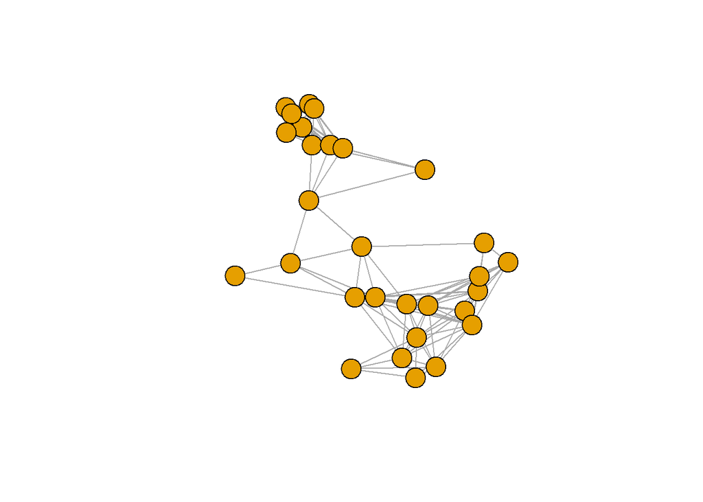

```r
plot(graphAmean, layout=coords, vertex.label=NA)
```

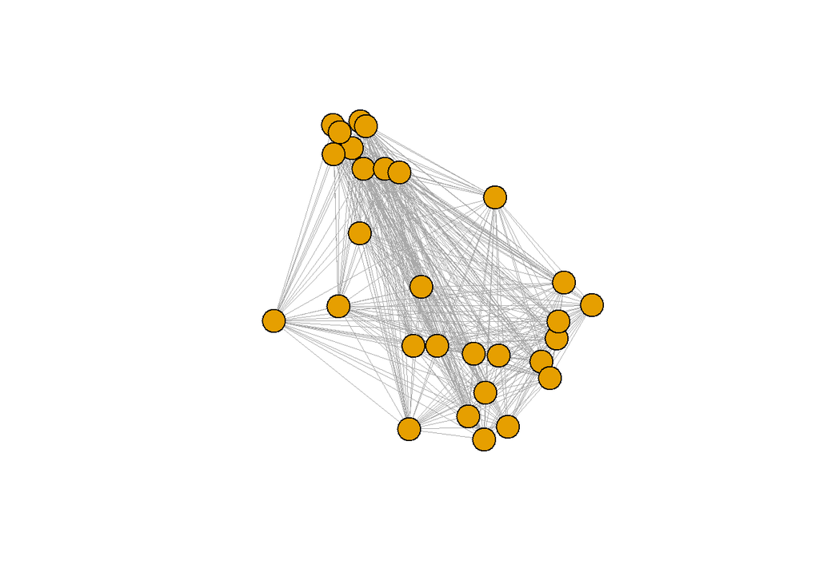

```r
plot(graphAprob, layout=coords, edge.width=E(graphAprob)$weight, vertex.label=NA)
```

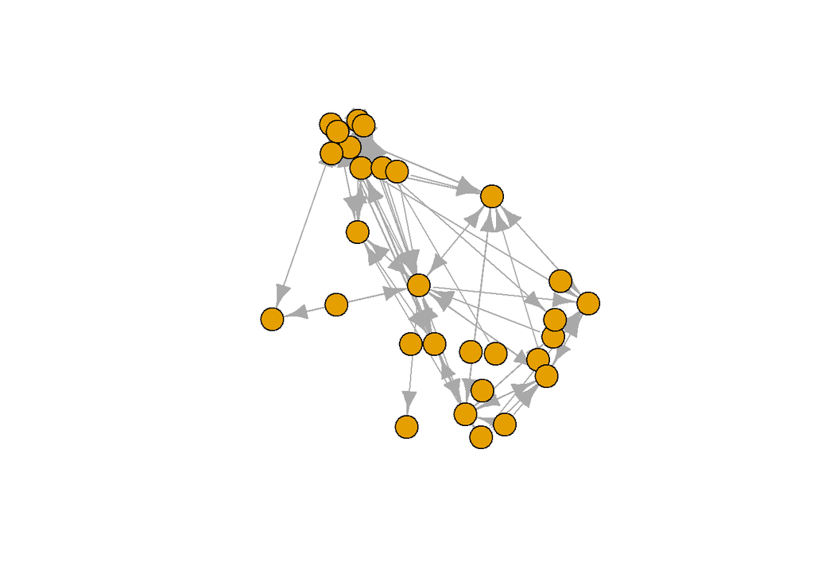

```r
plot(graphAobs, layout=coords, vertex.label=NA)
```

### Patch-scale connectivity

Node- or patch-level connectivity measures are often called (in network speak) “centrality” measures. We can also break such metrics down into “radial” or “medial” measures. Radial measures focus on quantifying flow that starts or terminates from a given patch. Common radial measures include degree (sum of number of links);

```r
aMeanDegree = degree(graphAmean)
aMeanDegree
```

```
##  [1]  4 11  5  8  7  2 12  4  6 10  5  8  8 10 10 10  8  6  8  4  8 11 11  8 11
## [26] 12 10 11  8
```

strength (sum of weights of links to/from patch);

```r
aMeanStrength = strength(graphAmean)
aMeanStrength
```

```
##  [1]  4 11  5  8  7  2 12  4  6 10  5  8  8 10 10 10  8  6  8  4  8 11 11  8 11
## [26] 12 10 11  8
```

eigenvector centrality (relative number of indirect links through neighbors);

```r
aMeanEigen = eigen_centrality(graphAmean)
aMeanEigen$vector
```

```
##  [1] 0.29029732 0.84602960 0.38487008 0.01517647 0.59645744 0.11317918
##  [7] 0.99627253 0.25807420 0.06966161 0.02313840 0.23753292 0.01517647
## [13] 0.01517647 0.02313840 0.02313840 0.84730236 0.01517647 0.34545630
## [19] 0.01517647 0.01452671 0.68155234 0.96360177 0.89978222 0.01517647
## [25] 0.96360177 1.00000000 0.82645757 0.90658930 0.66135131
```

and closeness centrality (inverse of the average shortest-path distance from patch to all other connected patches).

```r
aMeanClose = closeness(graphAmean)
aMeanClose
```

```
##  [1] 0.01041667 0.01639344 0.01075269 0.01052632 0.01265823 0.01315789
##  [7] 0.01666667 0.01369863 0.01587302 0.01333333 0.01639344 0.01052632
## [13] 0.01052632 0.01333333 0.01333333 0.01369863 0.01052632 0.01724138
## [19] 0.01052632 0.01234568 0.01298701 0.01388889 0.01639344 0.01052632
## [25] 0.01388889 0.01408451 0.01351351 0.01388889 0.01282051
```

Medial measures quantify the number of paths that flow through a patch. The most common one is betweenness centrality which quantifies the number of shortest paths between all patches in the network that go through a particular patch.

```r
aProbBetween = betweenness(graphAprob, weights=1/E(graphAprob)$weight)
aProbBetween
```

```
##  [1]   0  26   0   0   0   0  22  19 111   3   0   0   0   0  10   1   0 130   0
## [20]  30   0   3  14   0   6   2   0   2   0
```

### Landscape-scale connectivity

```r
connectance = edge_density(graphAmean)
connectance
```

```
## [1] 0.2906404
```

Next we will look at the integral index of connectivity which is also based on a binary network. Values range from 0 (no habitat) to 1 (entire landscape is habitat), and the value declines with loss of each patch or loss of non-redundant links.

```r
AL = 63990 # Approximate study area in km^2

#Create a matrix of shortet paths
nlMat = distances(graphAmean)

#In cases where you have isolated patches, we assign an arbitrarily large value
nlMat [is.infinite(nlMat)] = 1000

iicMat = outer(area, area)/(1+nlMat)
iic = sum(iicMat)/AL^2
iic
```

```
## [1] 0.002805411
```

Lastly, we’ll look at probability of connectivity which is one of the most frequently used metrics. This metric is used to describe the probability that two random points in a landscape are reachable from each other given a set of habitat patches and links among them.

```r
pStarMat = distances(graphAprob, weights=E(graphAprob)$weight)

# Back-transform to probabilities
pStarMat = exp(-pStarMat)

# Numerator of PC
pcNum = outer(area, area)*pStarMat

# Probability of connectivity
pc = sum(pcNum)/AL^2
pc
```

```
## [1] 0.00595698
```